# MATH 340: Common Discrete Distributions

Hitchman

# The 4 commands of named distributions

**In R**  
We can access all the common, named distributions we encounter in this class, and we use four commands to work with them. For a distribution named `___`:

- `d___(x,...)` | Density function, $p(x)$
- `p___(q,...)` | Cumulative probability, $P(X\leq q)$
- `q___(p,...)` | Quantiles, finds $x$ such that $P(X \leq x) = p$
- `r___(n,...)` | Random sample of size $n$ from the distribution

We look at each of these for the binomial distribution next.

# Binomial Distribution `binom`

**The Scene**

We have a sequence of **Bernoulli trials**: A chance experiment with two possible outcomes: *success* and *failure*, and the probability of success is $p$, and the probability of failure is $1-p$.

Let the random variable $X$ denote the number of successes in $n$ independent trials of this chance experiment. Then $X$ is called a binomial random variable with parameters $n$ and $p$.

**Notation**  
$X \text{ is } b(n,p)$ means $X$ counts number of successes in $n$ Bernoulli trials, when probability of success on any given trial is $p$.

**The space of $X$** is $x = 0, 1, \ldots, n$.

**Probability density function**
For $x = 0, 1, \ldots, n$,
$$p(x)={n \choose x}p^x(1-p)^{n-x}.$$

Sometimes it is convenient to let $q = 1-p$ so $q$ represents the probability of failure in a Bernoulli trial, in which case $p(x) = {n \choose x}p^xq^{n-x}$

**The binomial distribution in R**

## `dbinom()` - density function

> `dbinom(2,5,.3)` returns the probability of $X=2$ successes in $n=5$ trials in a binomail distribution where $p = .3$ is the probability of success on each trial. That is, `dbinom(2,5,.3)` returns
> $${5 \choose 2}(.3)^2(.7)^3.$$

```r
dbinom(2,5,.3)
```

```
## [1] 0.3087
```

As a check:

```r
choose(5,2)*(.3)^2*(.7)^3
```

```
## [1] 0.3087
```

## `pbinom()` - cumulative prob.

> `pbinom(q,n,p)`returns the cumulative probability $P(X \leq q)$ for $X \sim b(n,p)$:
> $$\sum_{x=0}^q p(x)=\sum_{x=0}^q{n \choose
> x}p^x(1-p)^{n-x}.$$

So `pbinom(2,5,.3)` should return $P(X \leq 2)$ when $X$ is $b(5,.3)$:

```r
pbinom(2,5,.3)
```

```
## [1] 0.83692
```

As a check:

```r
dbinom(0,5,.3)+dbinom(1,5,.3)+dbinom(2,5,.3)
```

```
## [1] 0.83692
```

## `qbinom()` - quantiles

> `qbinom(.95,100,.5)` returns the value in the $b(100,.5)$ distribution that marks the 95th percentile: the value below which one finds 95% of the distribution:

```r
qbinom(.95,100,.5)
```

```
## [1] 58
```

In other words, if $X$ is $b(100,.5)$ (e.g., flip a fair coin 100 times and count how many heads you get), about 95% of the time you would find $X \leq 58$.

We can check this:

```r
pbinom(58,100,.5)
```

```
## [1] 0.955687
```

## `rbinom()` - sampling

> `rbinom(10,20,.4)` will generate a random sample of size 10 drawn from a $b(20,.4)$ distribution. This sample is stored as a vector

```r
rbinom(10,20,.4)
```

```
##  [1]  6  8  9  7 12  9  8  7  8 10
```

We can use `r___` to run simulations, and to visualize the shape of a distribution.

For a **discrete distribution** we can use `barplot()` and `table()` to tabulate the results. The `table()` command gives the total counts for each possible outcome, and the `barplot()` command applied to a table visualizes those counts.

```r
sim.data = rbinom(1000,20,.4) # draw a random sample of size 1000 from the binomial distribution b(20,.4).
table(sim.data)
```

```
## sim.data
##   2   3   4   5   6   7   8   9  10  11  12  13  14  15
##   2  14  39  76 134 146 167 168 124  57  46  17   9   1
```

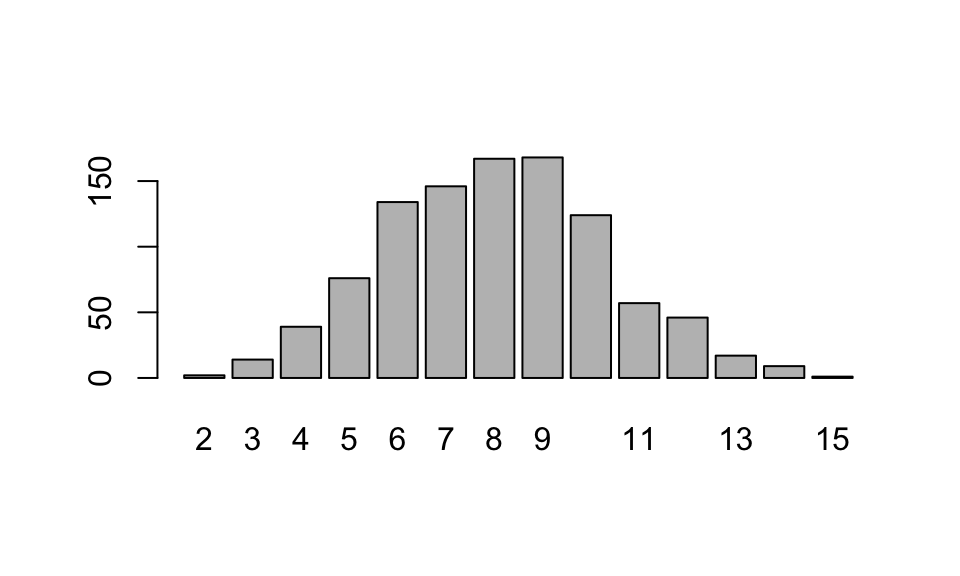

```r
barplot(table(sim.data))
```

# Geometric Distribution `geom`

**The Scene**  
As with the binomial distribution, we consider a sequence of Bernoulli trials (probability of success is $p$, probability of failure is $q = 1-p$). Instead of counting how many successes in $n$ trials, we are interested in counting the number ot trials until our first success.

Assume we repeat the experiment until we observe a success. Let the random variable $X$ denote the number of trials up to and including this first success. Then $X$ is called a *geometric random variable* with parameter $p$.

**Notation**  
$X \text{ is geom}(p).$

**The space of $X$** is $x = 1, 2, \ldots$

**Probability density function**
For $x = 1, 2, 3, \ldots$,
$$p(x)= q^{x-1}p.$$

> The geometric distribution in R counts failures, not total trials.

**In R**, `geom` is counting the number of failures until the first success, not the total number of trials up to and including the first success.

As with the `binom` distribution, we can use the `d___`, `p___`, `q___`, and `r___` commands to determine probabilities for particular values of x, cumulative probabilites, quantiles, and random samples, respectively.

> `dgeom(4,.3)` gives the probability of seeing 4 failures before the first success in a Bernoulli trial in which $p = .3$

```r
dgeom(4,.3)
```

```
## [1] 0.07203
```

> `pgeom(4,.3)` gives the probability of seeing 4 or fewer failures before the first success in a sequence of Bernoulli trials in which $p = .3$

```r
pgeom(4,.3)
```

```
## [1] 0.83193
```

and the following line gives the probability of seeing more than 4 failures prior to the first success:

```r
1-pgeom(4,.3)
```

```
## [1] 0.16807
```

> **Example:**  
> Roll a fair 6-sided die until a four comes up, and let $X$ denote the rolls up needed to see that first four. Repeat this game 10,000 times, and plot the frequency distribution for $X$.

Strategy:

1. Note that this game is a Bernoulli trial, where “success” means rolling a 4 and “failure” means not rolling a four. So $p = 1/6$, and $q = 5/6$.
2. Take a random sample of size 10000 from the `geom` distribution in R with the `rgeom()` method (which records the number of failures, not the number of trials).
3. Add one to each value in the sample to get the number of trials.
4. barplot the table!

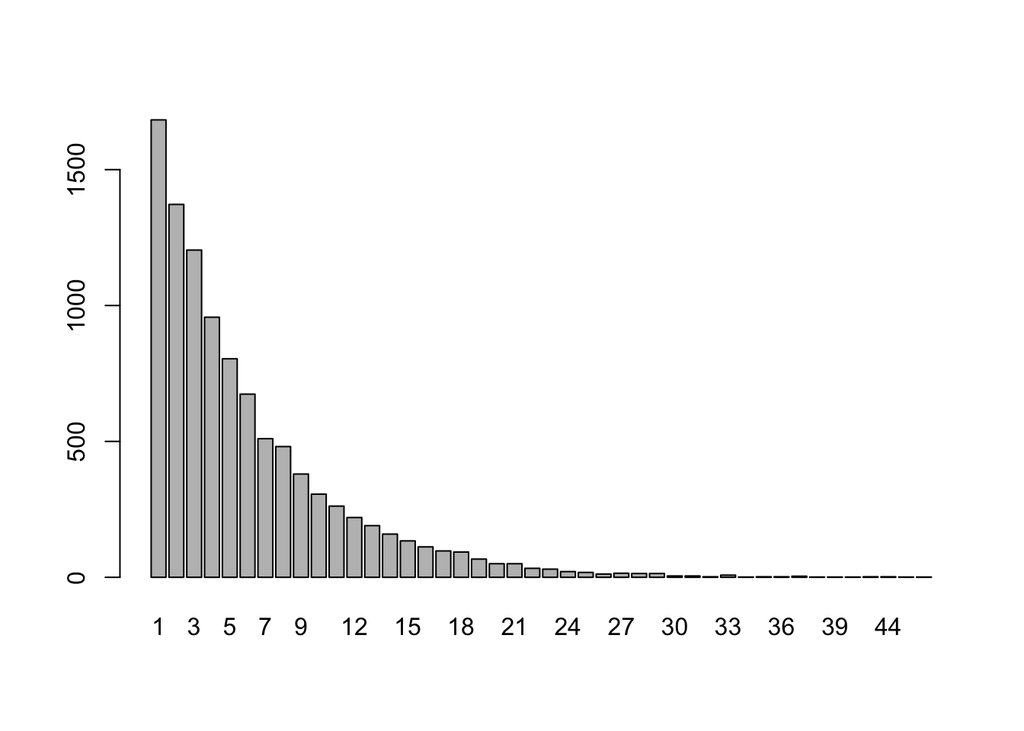

```r
results=rgeom(10000,1/6)+1
barplot(table(results))
```

OMG, notice that one depressing game required 48 rolls to see my first 4.

# Negative Binomial Distribution `nbinom`

**The Scene**  
Again, we consider a sequence of Bernoulli trials (probability of success is $p$, probability of failure is $q = 1-p$).

For instance, if we set $r = 3$, then $X = 7$ for the following sequence of Bernuoulli trials ($S$ stands for success, $F$ for failure)
$$F F F S F S S F S F F S \ldots$$
since the third $S$ occurs on the 7th trial.

In the case $r = 1$ the negative binomial distribution is the geometric distribution.

**Notation**: $X$ is Nb$(r,p)$

**The space of $X$** is $x = r, r+1, r+2, \ldots$

**Probability density function**
For $x = r, r+1, r+2, $,
$$p(x)=
\binom{x-1}{r-1}p^{r}q^{x-r}.$$

> **Example:**  
> A study indicates that an exploratory oil well drilled in a particular region should strike oil with probability 0.2. Find the probability that the third oil strike comes on the 10th well drilled.

Here, if $X$ equals the number of wells drilled until the company gets its third strike, then $X$ is Nb(3,0.2), and the answer to this question is $P(X=10)$ which is
$$P(X=10)=\binom{9}{2}0.2^{3}.8^{7}.$$

```r
round(choose(9,2)*.2^3*.8^7,4)
```

```
## [1] 0.0604
```

**In R** this distribution is accessed using `nbinom`, but this distribution, like `geom`, focuses on the number of failures, not total trials. If we want to know the probability that our third success occurs on the 10th trial, this is equivalent to the probability of having 10-3 = 7 failures before getting our third success, which can be computed in R as

```r
dnbinom(7,3,.2) # 7 failures to get 3rd success, p = .2
```

```
## [1] 0.06039798
```

Visualizing $X \sim Nb(3,.2)$

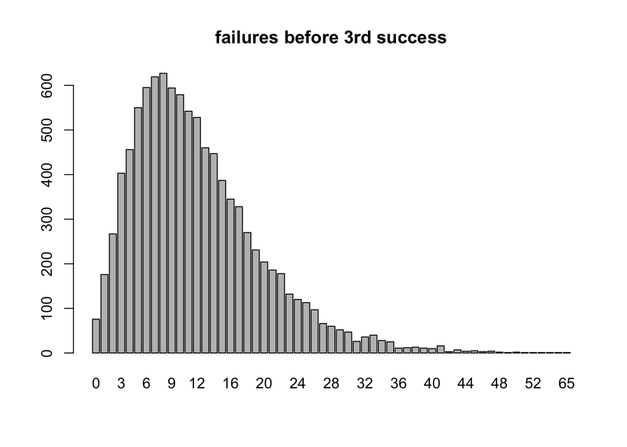

```r
r=3 #going until we get 3rd success
trials=10000 #draw a random sample of this size
p=.2 #probability of success on any given Bernoulli trial
failure.count=rnbinom(trials,r,p)
barplot(table(failure.count),main="failures before 3rd success")
```

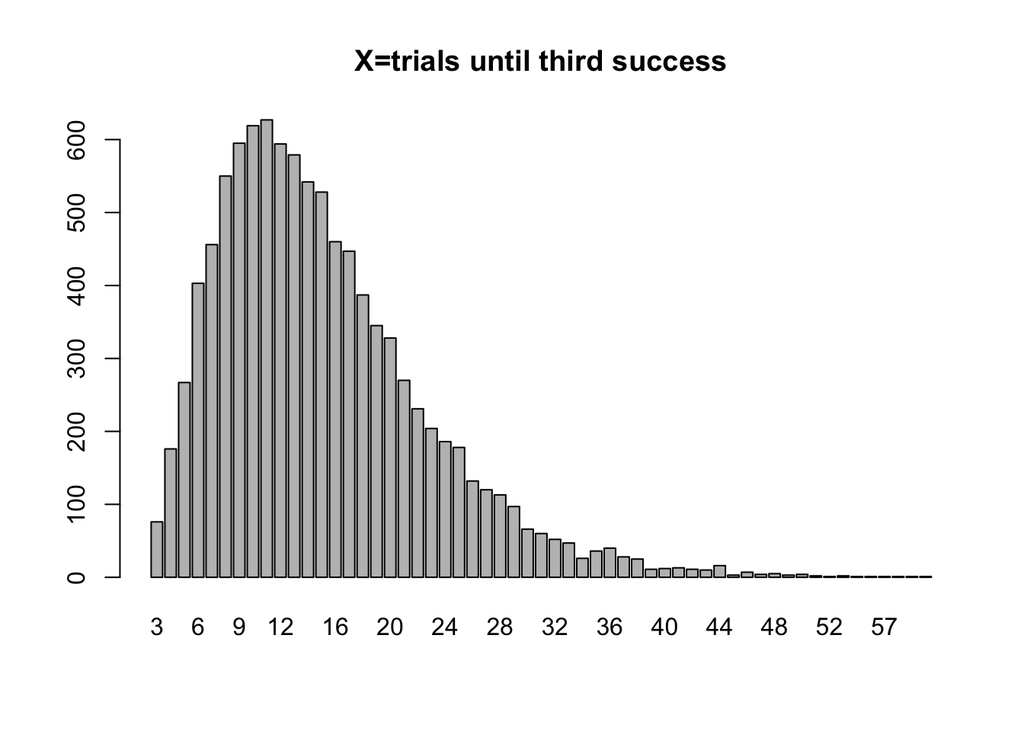

```r
trial.count=failure.count+r
barplot(table(trial.count),main="X=trials until third success")
```

# Hypergeometric Distribution `hyper`

**The Scene**  
A finite population has $N$ elements that possess one of two characteristics. Say we have a jar of $N$ marbles, $m$ of them are red and $n$ of them are black (so $m + n = N$). We draw a sample of size $k$, and let $X$ denote the number of red marbles in the jar.

Then $X$ is called a *hypergeometric random variable* with parameters $m$, $n$, and $k$.

**Notation**: $X$ is hyperg$(m,n,k)$

**The space of $X$** is $x = 0,1,2,\ldots,k$ subject to the restriction that $x \leq m$ and $k - x \leq n$.

**Probability density function**
The probability function is
$$p(x)=
\frac{\binom{m}{x}\binom{n}{k-x}}{\binom{m+n}{k}}.$$

**In R** Use `hyper`.

> A group of 6 seals and 4 pelicans hang at the beach, and they select a random subset of size 5 to play beach volleyball. Let $X$ = the number of pelicans chosen.  
> Here, $X$ is hypergeometric with parameters $m = 4$ (4 pelicans), $n = 6$ (6 seals) and $k = 5$ (sample size).  
> The probability that $X = 2$ is

```r
choose(4,2)*choose(6,3)/choose(10,5)
```

```
## [1] 0.4761905
```

We can also use the built in command `dhyper(x,m,n,k)`

```r
dhyper(x=2,m=4,n=6,k=5)
```

```
## [1] 0.4761905
```

> **Good Potatoes Bad Potatoes**  
> A truck has 500 potatoes, 50 of which are bad, the rest are good. We sample 10. What is the probability that more than 3 are bad?

If $X$ equals the number of bad potatoes in the sample, then $X$ is hypergeometric with parameters $m = 50$, $n=450$, and $k = 10$. So
$$P(X > 3) = 1 - P(X \leq 3)$$
which can be calculated with the cumulative probability command `phyper`:

```r
1-phyper(3,50,450,10)
```

```
## [1] 0.01186118
```

# Poisson Distribution `pois`

**The Scene**  
The Poisson probability distribution can provide a good model for the number of occurrences $X$ of a rare event in time, space, or some other unit of measure. A Poisson random variable $X$ has one parameter, $\lambda$, which is the average number of occurrences of the rare event in the indicated time (or space, etc.)

**Notation**: $X$ is Poisson$(\lambda)$.

**The space of $X$** is $x = 0,1,2,\ldots,$ (countably infinite!)

**Probability density function**
The probability function is
$$p(x)=\frac{\lambda^x}{x!}e^{-\lambda}$$

**In R** use `pois`.

> **Example**: Suppose $X$ is Poisson(5). Determine $P(X \geq 10)$.

Note: $P(X \geq 10) = 1-P(X < 10)= 1-P(X \leq 9)$. So, using `ppois()` we have

```r
1-ppois(9,5)
```

```
## [1] 0.03182806
```

> **Example**: The number $X$ of typos on a page in a textbook follows a Poisson distribution with an average number of 2 typos per page. (a) If you pick a page at random, what is the probability it contains 0 typos? (b) According to this model, 99% of the pages have no more than how many typos?

```r
dpois(0,2)
```

```
## [1] 0.1353353
```

```r
qpois(.99,2)
```

```
## [1] 6
```

## Poisson Process

Again, suppose $X$ denotes the number of occurrences of a rare event in time, space, or some other unit of measure.

The process by which an event happens is called a **Poisson process** if the following holds:

1. The dimension over which $X$ is measured can be subdivided into $n$ small pieces, within which the event can occur *at most once*.
2. In each small piece, the probability of seeing one occurrence is the same, say $p$, and $p$ is proportional to the length of the subinterval (as $n$ grows, $p$ shrinks, but $np$ remains constant).
3. Occurrences in all the small pieces are independent from one another.

In other words, recording the number of occurrences of the event in each small piece is a Bernoulli trial (1 with probability $p$, or 0 with probability $1-p$), and if there are $n$ small pieces, then $X$ is approximately $b(n,p)$.

> For large $n$, if we let $\lambda = np$, Poisson$(\lambda)\sim b(n,p)$.

Compare the table of probabilities for $b(10,.4)$, $b(40,.1)$, and $b(400,.01)$ with those of a Poisson(4) distribution. For all 3 binomial distributions $np = 4$, so as $n$ gets larger, $b(n,p)$ should be a better approximation to Poisson(4):

Approximating a Poisson distn with Binomial distns

| x | b.10_.4 | b.40_.1 | b.400_.01 | Pois.4 |
| --- | --- | --- | --- | --- |
| 0 | 0.0060 | 0.0148 | 0.0180 | 0.0183 |
| 1 | 0.0403 | 0.0657 | 0.0725 | 0.0733 |
| 2 | 0.1209 | 0.1423 | 0.1462 | 0.1465 |
| 3 | 0.2150 | 0.2003 | 0.1959 | 0.1954 |
| 4 | 0.2508 | 0.2059 | 0.1964 | 0.1954 |
| 5 | 0.2007 | 0.1647 | 0.1571 | 0.1563 |
| 6 | 0.1115 | 0.1068 | 0.1045 | 0.1042 |
| 7 | 0.0425 | 0.0576 | 0.0594 | 0.0595 |

> **Rutherford/Geiger Data**  
> In a paper published in 1910 entitled “The Probability Variations in the Distribution of $\alpha$-particles”, they reported data collected that counted the number of “scintillations” in 72 second intervals caused by radioactive decay of a quantity of the element polonium.

Here’s the data:

```r
results=rep(0:14,c(57,203,383,525,532,408,273,139,45,27,10,4,0,1,1))
trials=length(results)
table(results)
```

```
## results
##   0   1   2   3   4   5   6   7   8   9  10  11  13  14
##  57 203 383 525 532 408 273 139  45  27  10   4   1   1
```

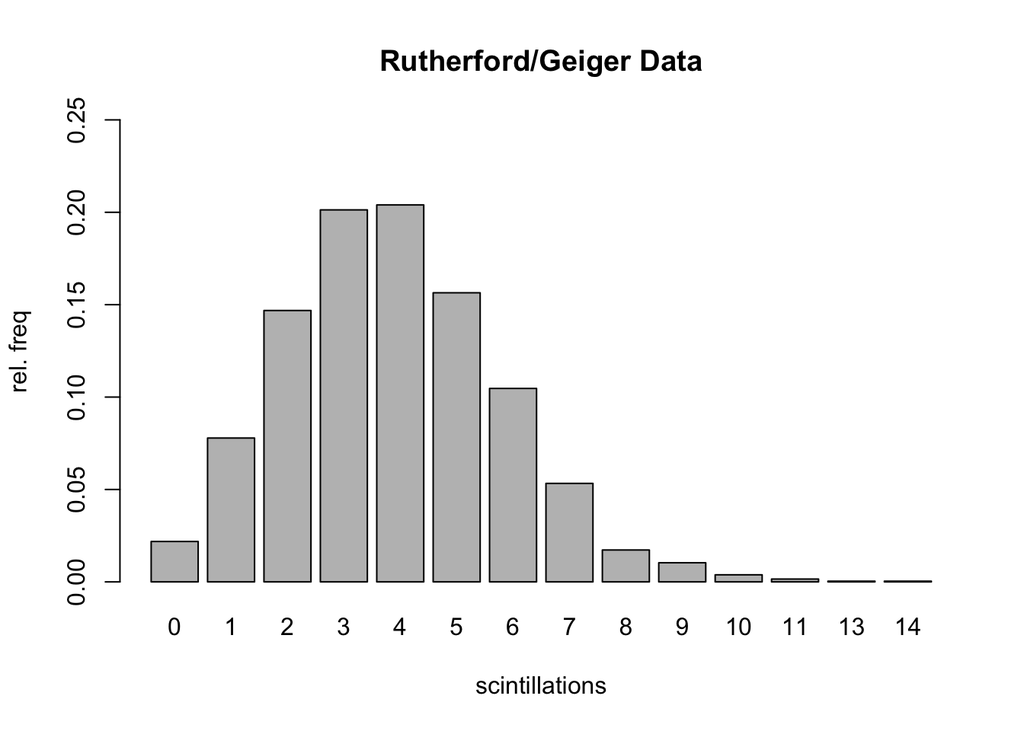

```r
barplot(table(results)/trials,
        ylim=c(0,.25),
        ylab="rel. freq",
        xlab="scintillations",
        main="Rutherford/Geiger Data")
```

Here’s the mean of the data (which gives average # of scintillations in 72 seconds):

```r
mean(results)
```

```
## [1] 3.871549
```

Let’s compare the observed relative frequencies to the theoretical probabilities associated with a Pois(3.87) distribution:

Fitting data with a Poisson distribution

| x | rel_freq | pois_prob |
| --- | --- | --- |
| 0 | 0.0219 | 0.0209 |
| 1 | 0.0778 | 0.0807 |
| 2 | 0.1469 | 0.1562 |
| 3 | 0.2013 | 0.2015 |
| 4 | 0.2040 | 0.1949 |
| 5 | 0.1564 | 0.1509 |
| 6 | 0.1047 | 0.0973 |
| 7 | 0.0533 | 0.0538 |
| 8 | 0.0173 | 0.0260 |
| 9 | 0.0104 | 0.0112 |
| 10 | 0.0038 | 0.0043 |
| 11 | 0.0015 | 0.0015 |
| 12 | 0.0000 | 0.0005 |
| 13 | 0.0004 | 0.0001 |
| 14 | 0.0004 | 0.0000 |

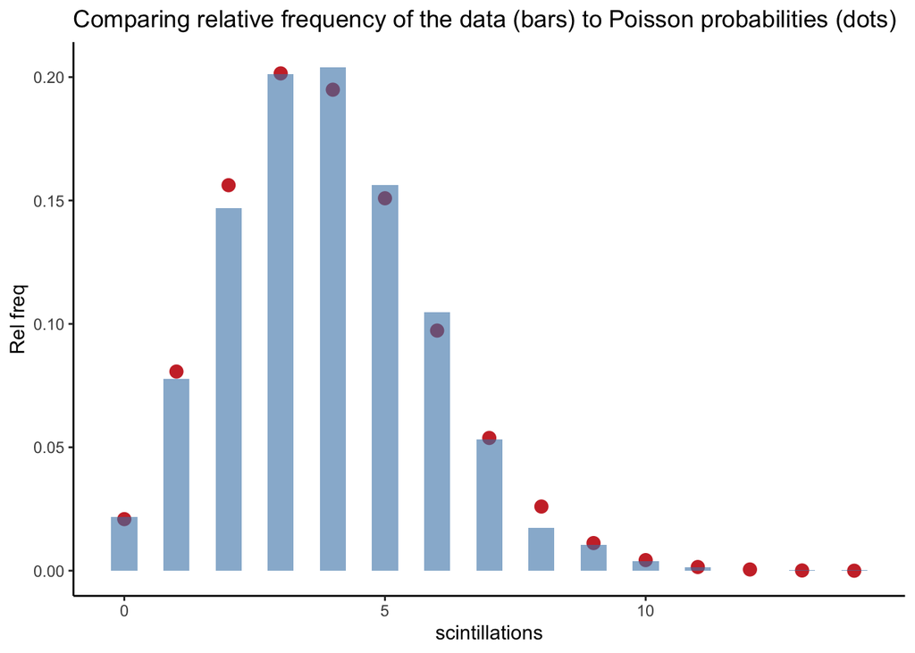

```r
ggplot(df)+
  geom_point(aes(x,pois_prob),col="brown3",size=3)+
  geom_col(aes(x,rel_freq),fill="steelblue",alpha=.6, width=.5)+
  ylab("Rel freq")+
  xlab("scintillations")+
  ggtitle("Comparing relative frequency of the data (bars) to Poisson probabilities (dots)")+
  theme_classic()
```